# Web traffic: five-day conditional-batch contribution penalties

## Data and week-like batching

Daily English Wikipedia pageviews for 30 articles span 2022-01-01 through 2024-12-31 in the bundled `inst/extdata/wiki_traffic.csv`. Covariates are the current day’s article views, in thousands; the response is the **next day’s** aggregate count. The aggregate is omitted from the predictors because it is the sum of the article series. The final covariate row is dropped because its next-day target is unavailable.

```r
wiki <- paper_wiki_data()
articles <- setdiff(names(wiki),c("date","target"))
range(wiki$date)
```

```
## [1] "2022-01-01" "2024-12-30"
```

```r
calc_moments(wiki[,articles])
```

```
##                   variable       mean     variance excess_kurtosis
## 1                    apple  12.261544 1.902069e+01      56.2106066
## 2                   google  33.130276 1.847081e+02      25.1941345
## 3                microsoft   9.095185 2.295141e+02    1034.9635327
## 4                   amazon  15.716311 3.427888e+01       1.0933171
## 5                     meta  15.704444 8.911856e+01       0.7407420
## 6                    tesla   8.460263 1.092988e+01      37.7697321
## 7                   nvidia   5.605834 3.720858e+01      69.7379955
## 8                   openai  12.216690 1.654244e+02      15.6533248
## 9                  chatgpt  66.750111 6.108049e+03       2.0631917
## 10 artificial_intelligence  15.391548 1.860638e+01      -0.4050504
## 11                 bitcoin   6.989986 1.003581e+01      16.7186200
## 12                ethereum   2.061052 1.925581e+00      11.9147578
## 13          cryptocurrency   4.392612 5.006687e+00      29.0228783
## 14                 netflix  18.477065 4.086947e+01      -0.8511692
```

[output cut: 16 more lines]

Models use one-year training windows refit monthly. Evaluation covariates span 2023-01-01 through 2024-12-30, with targets through 2024-12-31. We retain `walk = 5` for computational efficiency as a **five-day, week-like conditional batch**. Slices contain five consecutive daily rows (including weekends), restart each month, and may end with a shorter slice.

All covariates in the slice enter the penalty together. Responses in that slice do not enter fitting. The five-row procedure is therefore conditional on the batch’s covariates, not a five-day-ahead forecast issued using only information known on its first day. It is also not a weekly aggregate target: scoring remains at the daily next-day-count level. A deployment that does not know the batch covariates must supply predictor scenarios or use `walk = 1`. This distinction lets us retain the faster experiment without overstating its forecast-origin information set.

## Estimation

We use the Poisson log-link loss as a working conditional-mean objective, not a claim of a calibrated Poisson count distribution. `lambda = 0` isolates the contribution penalty; alpha is immaterial. The feature-specific ceiling is three times the absolute **training univariate Poisson slope**. This differs from the finance correlation rule. The gamma grid is fixed at `c(10, 100, 1000, 10000, 100000)`.

```r
wiki_L
```

```
## function (train_use, target_col, feature_cols, y_train)
## {
##     vapply(feature_cols, function(v) {
##         uni <- suppressWarnings(stats::glm(train_use[[target_col]] ~
##             train_use[[v]], family = "poisson"))
##         3 * abs(stats::coef(uni)[2])
##     }, numeric(1))
## }
```

```r
paper_wiki
```

```
## function ()
## {
##     rolling_enet(paper_wiki_data(), date_col = "date", target_col = "target",
##         alpha = 0, window_years = 1, method = c("capnet_walk",
##             "capnet", "postcap"), capnet_gamma = 0, walk_gamma = c(10,
##             100, 1000, 10000, 1e+05), min_obs = 200, eval_start = "2023-01-01",
##         family = "poisson", cap_formula = wiki_L, lambda_override = 0,
##         walk = 5, parallel = FALSE)
## }
```

The ordinary capnet fit with gamma zero supplies the uncapped baseline. Post-fit capping clips its slope contributions on the log-mean scale, retains the intercept, and exponentiates to get predicted counts. Batches are evaluated serially in this reproduction; changing independent execution order is not a statistical change to the experiment.

## Scores and diagnostics

The score is **squared-error out-of-sample R-squared**, not a deviance-based pseudo-R-squared. `calc_oos_r2` compares summed squared errors to an expanding mean of preceding evaluation responses and drops the first observation.

```r
summary_table <- paper_scores(results,"date")
knitr::kable(summary_table,digits=6)
```

| method | gamma | n | oos_r2 |
| --- | --- | --- | --- |
| Post-Fit Cap | 0e+00 | 730 | -1.433189 |
| Uncapped | 0e+00 | 730 | -9461.131198 |
| Walk-forward Capnet | 1e+01 | 730 | -602.165555 |
| Walk-forward Capnet | 1e+02 | 730 | -0.066141 |
| Walk-forward Capnet | 1e+03 | 730 | 0.407770 |
| Walk-forward Capnet | 1e+04 | 730 | 0.437681 |
| Walk-forward Capnet | 1e+05 | 730 | 0.408956 |

The complete grid is a sensitivity analysis. The plotted gamma is the one with the largest full-window score, chosen **retrospectively**. It is not a separately validated deployment choice, and its performance is not an unbiased estimate of a tuning procedure’s future performance.

The figure compares each method’s maximum absolute feature contribution on one shared logarithmic vertical axis. The axis compresses the isolated 2023 uncapped spike while keeping the smaller daily values visible. Its tick labels give contribution magnitudes on the original log-mean scale.

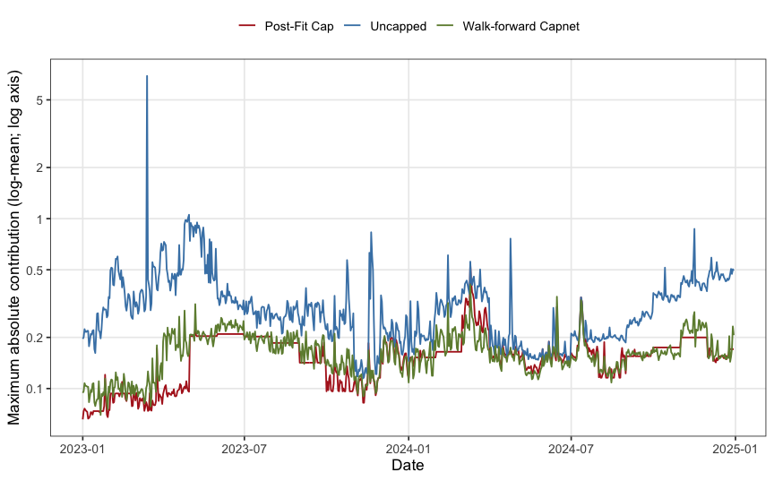

```r
walk_scores <- summary_table |> filter(method=="Walk-forward Capnet")
best_gamma <- walk_scores$gamma[which.max(walk_scores$oos_r2)]
plots <- paper_plots(results,"date",best_gamma,window=180,wiki=TRUE)
plots$contributions
```

Rolling scores use **180 scored observations**, consistent with the original vignette. Each window is summed directly to avoid cumulative-subtraction cancellation after a very large forecast error leaves the window. The pooled scores above and the 2024-only comparison below summarize predictive accuracy. The contribution figure computes the nonnegative maximum absolute contribution separately for each model and row, rather than tracking a reference model’s selected feature or plotting signed values.

```r
features <- c("google","microsoft","tesla","nvidia","chatgpt","netflix","sony","elon_musk","sam_altman","youtube")
knitr::kable(paper_snapshot(results,"date","2023-03-14",best_gamma,features),digits=3)
```

| feature | Uncapped | Post-Fit Cap | Walk-forward Capnet |
| --- | --- | --- | --- |
| google | 0.065 | 0.005 | 0.011 |
| microsoft | -0.046 | -0.046 | 0.055 |
| tesla | 0.051 | 0.051 | 0.053 |
| nvidia | -0.029 | -0.029 | -0.038 |
| chatgpt | 0.365 | 0.004 | 0.105 |
| netflix | 0.150 | 0.030 | 0.048 |
| sony | 0.080 | 0.080 | 0.068 |
| elon_musk | 0.016 | 0.003 | 0.008 |
| sam_altman | 0.004 | 0.004 | 0.067 |
| youtube | 6.915 | 0.001 | 0.025 |

These are selected features’ contributions to the log-mean; they exclude the intercept. They are not an additive decomposition of the count forecast error.

## 2024-only robustness comparison

```r
knitr::kable(paper_scores(results,"date",year=2024),digits=6)
```

| method | gamma | n | oos_r2 |
| --- | --- | --- | --- |
| Post-Fit Cap | 0e+00 | 365 | -1.112825 |
| Uncapped | 0e+00 | 365 | 0.539702 |
| Walk-forward Capnet | 1e+01 | 365 | 0.539598 |
| Walk-forward Capnet | 1e+02 | 365 | 0.542766 |
| Walk-forward Capnet | 1e+03 | 365 | 0.561793 |
| Walk-forward Capnet | 1e+04 | 365 | 0.569181 |
| Walk-forward Capnet | 1e+05 | 365 | 0.574311 |

This restricts the **same saved predictions** to covariate dates in calendar 2024 and recomputes the expanding benchmark within that subperiod. It does not refit, retune gamma, or carry the benchmark mean over from 2023. The plotted full-window gamma remains fixed for interpreting this comparison.

```r
stopifnot(all(is.finite(as.numeric(results$predictions$predicted))))
results$diagnostics |> group_by(method,requested_gamma) |>
  summarise(missing=sum(missing),
    reduced_rows=sum(effective_gamma<requested_gamma,na.rm=TRUE),
    unsuccessful_stops=sum(!is.na(convergence)&convergence<0&convergence != -1001),
    .groups="drop")
```

```
## # A tibble: 6 × 5
##   method              requested_gamma missing reduced_rows unsuccessful_stops
##   <chr>                         <dbl>   <int>        <int>              <int>
## 1 Walk-forward Capnet              10       0            0                  0
## 2 Walk-forward Capnet             100       0            0                  0
## 3 Walk-forward Capnet            1000       0            0                  0
## 4 Walk-forward Capnet           10000       0            0                  0
## 5 Walk-forward Capnet          100000       0            0                  0
## 6 capnet                            0       0            0                  0
```

The exported mean diagnostics report held-out mean observed/predicted counts and average Pearson-type squared residuals. They are descriptive and do not turn the working Poisson loss into a validated full predictive distribution.

Run `bash tools/reproduce_paper.sh` from the repository root for a fresh source install and all results. `params = list(rerun = TRUE)` reruns fitting when rendering this report. Raw fits/predictions, the 2024-only scores, plotted maxima, package versions, and input/source checksums are saved under `manuscript/results/wiki*`.